# COPASProfiler

# COPASProfiler Package Description

COPASProfiler is an R package that can view, filter, classify and analyze COPAS Large Particle Flow Cytometer. Below is a tutorial on how to install the package, get training data and how to use the functions and pipelines.

# COPASProfiler Model Creation pipeline

## Introduction

The COPAS Large Particle Flow Cytometer (COPAS FC) allows fluorescence screening of a large number of worms in a short time. However, the output of machine is hard to interpret. Worms that go in the COPAS FC can go in straight or turned over themselves. If the worm is turned on itself, that will overlap the florescence expression of its body and will create a different expression pattern in the data compared to a worm that went in straight. The COPASProfiler package was created to help visualize the objects better. This tutorial is intended to teach users how to create their own SVM model to distinguish good worms (Worms that went in straight) from other unwanted objects.

## How to get the package

You can access the package’s GitHub through this link: https://GitHub.com/ksnksa/COPASProfiler You can also run this code to directly download the package in Rstudio.

```r
devtools::install_github("ksnksa/COPASProfiler/COPASProfiler")
```

To load the package, simply run the following code.

```r
library("COPASProfiler")
```

## What data set to use

The COPAS FC outputs more than one file for each run. (NameOfRun).txt which contains the general information of all the objects and four (NameOfRun)_ch#_prf.txt files (the # goes from 0 to 3) which contain the data from each channel. We’ll only be using the last four files. If you just want to follow this example, the tutorial loads the example files directly from our GitHub repository.

## How to get the annotated IDs

We also use another csv file that contains annotated objects and their IDs. We’ll be using this file to create our model. To create your own annotation, you can go to our [website](https://wormbuilder.dev/WormProfiler/). The website allows you to visualize the object’s channel data.

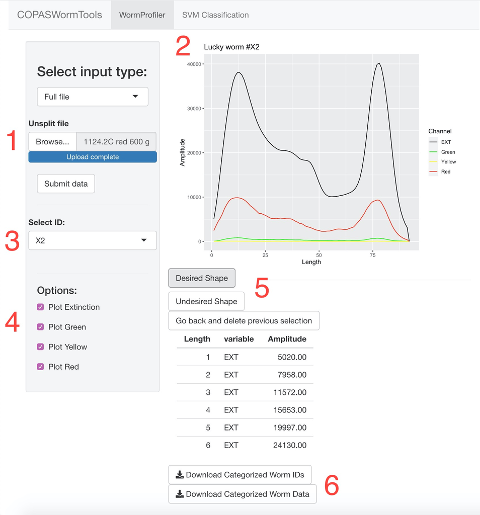

1: Load the correct channel data file/s then press submit. 2: The output plot of the selected object. 3: Here you can select which object ID you’d like to view. 4: You can check which channel you’d like to be in the plot. 5: The buttons allow you to annotate the objects. Desired Shape will annotate this object as a good worm, and Undesired Shape this object as a bad worm. Note: the annotation label does not matter, therefore if the user would annotate profiles based on specific fluorescence expression the same principle applies. After annotating any number of objects, a button will pop up to download the annotated IDs (Next to the number 6).

## Running the pipeline

```r
##Loading the libraries
library(ggplot2)
library(dplyr)
library(scales)
library(COPASProfiler)
library(kernlab)
library(jmotif)
```

### Loading the data

In this example, we used a sample data set generated by the [Laboratory of Synthetic Genome Biology](https://syngenbio.kaust.edu.sa/). You can run the following code to use the same data set and annotated IDs files we’re using. Ch0D, Ch1D, Ch2D, Ch3D, are the paths for each channel profile. GoodIDD is the path to the annotated IDs csv file.

```r
#Channel directory taken from the COPASProfiler GitHub repository
#When using your own data simply change these links to the file directory of the channels.
Ch0D <- 'https://raw.githubusercontent.com/ksnksa/COPASProfiler/main/Data/1123.2C%20red%20500%20green%20600%20gain%202_ch0_prf.txt'
Ch1D <- 'https://raw.githubusercontent.com/ksnksa/COPASProfiler/main/Data/1123.2C%20red%20500%20green%20600%20gain%202_ch1_prf.txt'
Ch2D <- 'https://raw.githubusercontent.com/ksnksa/COPASProfiler/main/Data/1123.2C%20red%20500%20green%20600%20gain%202_ch2_prf.txt'
Ch3D <- 'https://raw.githubusercontent.com/ksnksa/COPASProfiler/main/Data/1123.2C%20red%20500%20green%20600%20gain%202_ch3_prf.txt'
#CSV file containing the levels (or annotation) for each worm in our training set.
GoodIDD <- 'https://raw.githubusercontent.com/ksnksa/COPASProfiler/main/Data/1123.2c.csv'
```

### Setting up the parameters

```r
#Setting up the parameters we need for the analysis
# Max amplitude an object can have
# Anything more will be filtered out
MaxAmp <- 35000
# Minimum and maximum time of flight for each object
MinLength <- 51
MaxLength <- 900
# Which channel the pipeline will work on
# 1 is for Channel 0, 2 is for Channel 1
# 3 is for Channel 2, 4 is for Channel 3
ChannelNumber <- 1
```

### Example run

#### Loading the training set

First we load up the channel data and apply an initial filter. Then we load up the annotated IDs csv file and create a variable that has the data for the worms that were annotated.

```r
# The ReadChannel function simply takes in the channel directories and returns a list with all
# the channels data.
channellist <- ReadChannel(Ch0D,Ch1D,Ch2D,Ch3D)
# The PreProcessData function removes profiles outside of the provided thresholds, removes trailing zeros for each profile
# applies the PAA function to uniform the length, and applies z-score normalization on the Y axis.
ModData <- PreProcessData(channellist, MinLength,MaxLength,MaxAmp, ChannelNumber)
# The CreateTrainingSetIDs function translates the annotated IDs csv
# file to the data we have and gives out the index of the worms that are annotated.
WormIDs <- CreateTrainingSetIDs(ModData,GoodIDD)
```

#### Option 1: Model performance on the same individual set

To validate the model performance on the same set, one must split the annotated set into two separate sets first. The user can specify what percent of the annotated data set will be the training set. We recommend a 50/50 split for an initial validation test.

```r
# If the SplitPercent variable is 0.5, then half of the annotated set will
# will be a training set and the other half will be a prediction set.
SplitPercent <- 0.5
DataSetList <- RandomTrainingSet(ModData, WormIDs, round(length(WormIDs[[1]]) * SplitPercent),round(length(WormIDs[[2]]) * SplitPercent))
# TSet is the training set, and PSet is the prediction set.
TSet <- DataSetList[[1]]
PSet <- DataSetList[[2]]
```

Next we will use the training set to make a classification model. The model will then classify the prediction set. The model performance will be calculated by comparing the predicted labels against the real labels of the prediction set. Additionally, the cross parameter in the “ksvm” function will perform k-fold cross validation which will give us some insight on the model performance .

```r
# Creating the model using the ksvm function
model <- ksvm(as.matrix(TSet[,1:(MinLength-1)]), as.factor(TSet[,MinLength]),type = 'C-svc', kernel= "rbfdot",scaled=FALSE, cross = 5)
# Running the model against the prediction set.
pred <- predict(model,PSet)
# The positive variable will save the ID names of all profiles that were labeled as "2" or "good" by the model.
Positive <- rownames(PSet[which(pred==2),])
# To find which of these IDs are actually True Positives (or correct classification)
# We will count how many IDs are in the WormsIDs[[1]] variable which will contain all
# the annotated IDs of the good profiles.
TP <- sum((Positive %in% WormIDs[[1]]), na.rm = TRUE)
# we will repeat the same process with the "bad" or "1" profiles.
Negative <- rownames(PSet[which(pred==1),])
TN <- sum(Negative %in% WormIDs[[2]],na.rm = TRUE)
# The code below will calculate the False positive number and the false negative numbers
FP <- length(Positive) - TP
FN <- length(Negative) - TN
# The code below will print out the confusion matrix results of the Model
Accuracy <- ((TP + TN) / (length(Positive) + length(Negative))) * 100
Precision <- TP/(TP + FP) * 100
Sensitivity <- TP/(TP + FN) * 100
Specificity <- TN/(TN+FP) * 100
paste("Model Accuracy is: ", round(Accuracy,digits=2), '% ','Precision: ',round(Precision,digits=2),'% ',
      'Sensitivity: ',round(Sensitivity,digits=2),'% ','Specificity: ',round(Specificity,digits=2),'%',sep='')
```